# Lab 2

Robert Hijmans

August 28, 2018

## Manipulación de datos como vectores

Ejemplo SpatialPolygons

```r
library(raster)
library(rgeos)
library(rgdal)
f <- system.file("external/lux.shp", package="raster")
library(raster)
p <- shapefile(f)
p
```

```
## class       : SpatialPolygonsDataFrame
## features    : 12
## extent      : 5.74414, 6.528252, 49.44781, 50.18162  (xmin, xmax, ymin, ymax)
## crs         : +proj=longlat +datum=WGS84 +no_defs +ellps=WGS84 +towgs84=0,0,0
## variables   : 5
## names       : ID_1,     NAME_1, ID_2,   NAME_2, AREA
## min values  :    1,   Diekirch,    1, Capellen,   76
## max values  :    3, Luxembourg,   12,    Wiltz,  312
```

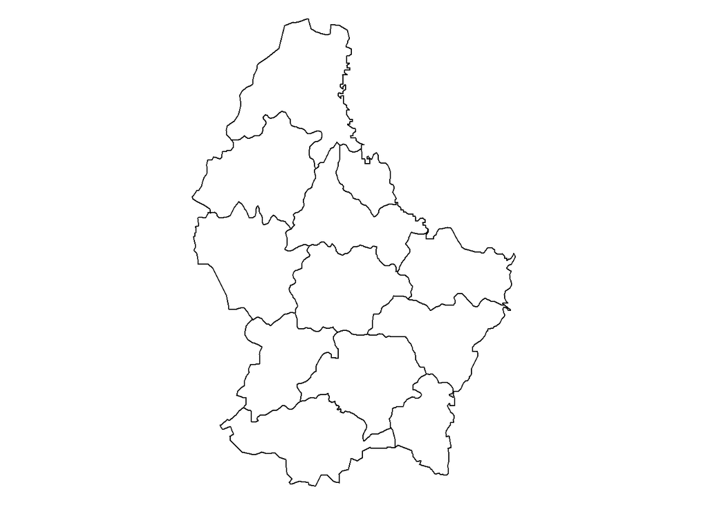

```r
par(mai=c(0,0,0,0))
plot(p)
```

7.1 Basico Las operaciones básicas se parecen mucho a cuando trabajamos con un data.frame.

7.1.1 Geometría y atributos: Para extraer los atributos (data.frame) de un Spatial object, use el comando data.frame. Podemos también extraer la geometria (no se necesita en la mayor parte de casos)

```r
## ----------------------------------------------
d <- data.frame(p)
head(d)
```

```
##   ID_1       NAME_1 ID_2     NAME_2 AREA
## 0    1     Diekirch    1   Clervaux  312
## 1    1     Diekirch    2   Diekirch  218
## 2    1     Diekirch    3    Redange  259
## 3    1     Diekirch    4    Vianden   76
## 4    1     Diekirch    5      Wiltz  263
## 5    2 Grevenmacher    6 Echternach  188
```

```r
g <- geom(p)
head(g)
```

```
##      object part cump hole        x        y
## [1,]      1    1    1    0 6.026519 50.17767
## [2,]      1    1    1    0 6.031361 50.16563
## [3,]      1    1    1    0 6.035646 50.16410
## [4,]      1    1    1    0 6.042747 50.16157
## [5,]      1    1    1    0 6.043894 50.16116
## [6,]      1    1    1    0 6.048243 50.16008
```

7.1.2 Variables Extraer una variable (igual que en un data.frame).

```r
## -----------------------
p$NAME_2
```

```
##  [1] "Clervaux"         "Diekirch"         "Redange"
##  [4] "Vianden"          "Wiltz"            "Echternach"
##  [7] "Remich"           "Grevenmacher"     "Capellen"
## [10] "Esch-sur-Alzette" "Luxembourg"       "Mersch"
```

Y de la misma manera, puede extraer un subset de una variable. Note cómo esto es distinto al ejemplo anterior. En el caso anterior estamos extrayendo los valores, mientras que en este obtenemos un SpatialPolygonsDataFrame con solo una variable.

```r
## ----------------------------
p[, 'NAME_2']
```

```
## class       : SpatialPolygonsDataFrame
## features    : 12
## extent      : 5.74414, 6.528252, 49.44781, 50.18162  (xmin, xmax, ymin, ymax)
## crs         : +proj=longlat +datum=WGS84 +no_defs +ellps=WGS84 +towgs84=0,0,0
## variables   : 1
## names       :   NAME_2
## min values  : Capellen
## max values  :    Wiltz
```

Podemos agregar una nueva variable.

```r
## --------------------------
set.seed(0)
p$new <- sample(letters, length(p))
p
```

```
## class       : SpatialPolygonsDataFrame
## features    : 12
## extent      : 5.74414, 6.528252, 49.44781, 50.18162  (xmin, xmax, ymin, ymax)
## crs         : +proj=longlat +datum=WGS84 +no_defs +ellps=WGS84 +towgs84=0,0,0
## variables   : 6
## names       : ID_1,     NAME_1, ID_2,   NAME_2, AREA, new
## min values  :    1,   Diekirch,    1, Capellen,   76,   a
## max values  :    3, Luxembourg,   12,    Wiltz,  312,   z
```

Podemos asignar nuevos valores a una variable existente.

```r
## -----------------------
p$new <- sample(LETTERS, length(p))
p
```

```
## class       : SpatialPolygonsDataFrame
## features    : 12
## extent      : 5.74414, 6.528252, 49.44781, 50.18162  (xmin, xmax, ymin, ymax)
## crs         : +proj=longlat +datum=WGS84 +no_defs +ellps=WGS84 +towgs84=0,0,0
## variables   : 6
## names       : ID_1,     NAME_1, ID_2,   NAME_2, AREA, new
## min values  :    1,   Diekirch,    1, Capellen,   76,   E
## max values  :    3, Luxembourg,   12,    Wiltz,  312,   Z
```

Podemos eliminar una variable:

```r
## -------------------
p$new <- NULL
```

7.1.3 Merge (combinar) Puede adherir una tabla (data.frame) con un Spatial* object usando merge.

```r
## -------------------------
dfr <- data.frame(District=p$NAME_1, Canton=p$NAME_2, Value=round(runif(length(p), 100, 1000)))
dfr <- dfr[order(dfr$Canton), ]
pm <- merge(p, dfr, by.x=c('NAME_1', 'NAME_2'), by.y=c('District', 'Canton'))
pm
```

```
## class       : SpatialPolygonsDataFrame
## features    : 12
## extent      : 5.74414, 6.528252, 49.44781, 50.18162  (xmin, xmax, ymin, ymax)
## crs         : +proj=longlat +datum=WGS84 +no_defs +ellps=WGS84 +towgs84=0,0,0
## variables   : 6
## names       :     NAME_1,   NAME_2, ID_1, ID_2, AREA, Value
## min values  :   Diekirch, Capellen,    1,    1,   76,   197
## max values  : Luxembourg,    Wiltz,    3,   12,  312,   845
```

7.1.4 Records - seleccionemos observaciones En líneas (records).

```r
## -------------------------
i <- which(p$NAME_1 == 'Grevenmacher')
g <- p[i,]
g
```

```
## class       : SpatialPolygonsDataFrame
## features    : 3
## extent      : 6.169137, 6.528252, 49.46498, 49.85403  (xmin, xmax, ymin, ymax)
## crs         : +proj=longlat +datum=WGS84 +no_defs +ellps=WGS84 +towgs84=0,0,0
## variables   : 5
## names       : ID_1,       NAME_1, ID_2,     NAME_2, AREA
## min values  :    2, Grevenmacher,    6, Echternach,  129
## max values  :    2, Grevenmacher,   12,     Remich,  210
```

7.2 Adhiera y Agregue 7.2.1 Adhiera Más datos de ejemplo. Objeto z, que consiste de 4 y z2 que consiste en 1 de esos 4 polygons.

```r
## ---- zzz----------------
z <- raster(p, nrow=2, ncol=2, vals=1:4)
names(z) <- 'Zone'
# coerce RasterLayer to SpatialPolygonsDataFrame
z <- as(z, 'SpatialPolygonsDataFrame')
z
```

```
## class       : SpatialPolygonsDataFrame
## features    : 4
## extent      : 5.74414, 6.528252, 49.44781, 50.18162  (xmin, xmax, ymin, ymax)
## crs         : +proj=longlat +datum=WGS84 +no_defs +ellps=WGS84 +towgs84=0,0,0
## variables   : 1
## names       : Zone
## min values  :    1
## max values  :    4
```

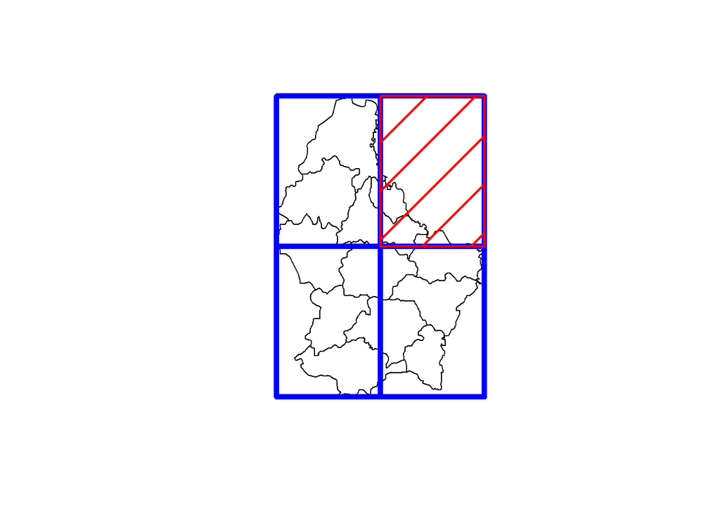

```r
z2 <- z[2,]
plot(p)
plot(z, add=TRUE, border='blue', lwd=5)
plot(z2, add=TRUE, border='red', lwd=2, density=3, col='red')
```

To append Spatial* objects of the same (vector) type you can use bind

```r
## -----------------------
b <- bind(p, z)
head(b)
```

```
##   ID_1       NAME_1 ID_2     NAME_2 AREA Zone
## 1    1     Diekirch    1   Clervaux  312   NA
## 2    1     Diekirch    2   Diekirch  218   NA
## 3    1     Diekirch    3    Redange  259   NA
## 4    1     Diekirch    4    Vianden   76   NA
## 5    1     Diekirch    5      Wiltz  263   NA
## 6    2 Grevenmacher    6 Echternach  188   NA
```

```r
tail(b)
```

```
##    ID_1     NAME_1 ID_2     NAME_2 AREA Zone
## 11    3 Luxembourg   10 Luxembourg  237   NA
## 12    3 Luxembourg   11     Mersch  233   NA
## 13   NA       <NA>   NA       <NA>   NA    1
## 14   NA       <NA>   NA       <NA>   NA    2
## 15   NA       <NA>   NA       <NA>   NA    3
## 16   NA       <NA>   NA       <NA>   NA    4
```

Note cómo es posible agregar Spatial* objects con nombres de atributos distintos (y dejar el resto como NA).

7.2.2 Agregue

[figure not shown]

```r
## ---- agg------------------
pa <- aggregate(p, by='NAME_1')
za <- aggregate(z)
plot(za, col='light gray', border='light gray', lwd=5)
plot(pa, add=TRUE, col=rainbow(3), lwd=3, border='white')
```

7.3 Sobreescribir 7.3.1 Borrar Borre partes de SpatialPolygons

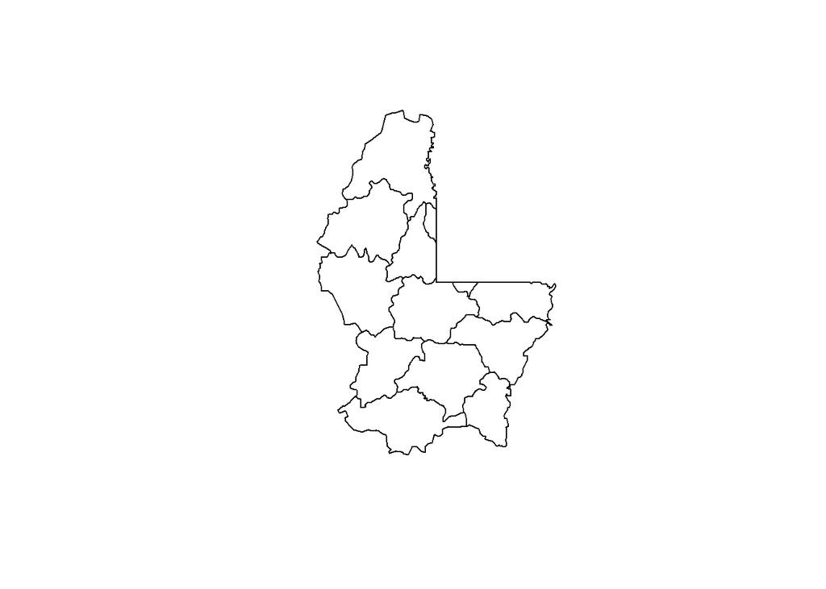

```r
## -----------------------
e <- erase(p, z2)
# or:
## ---- erase-------------
e <- p - z2
plot(e)
```

7.3.2 Intersecciones Intersecciones de SpatialPolygons

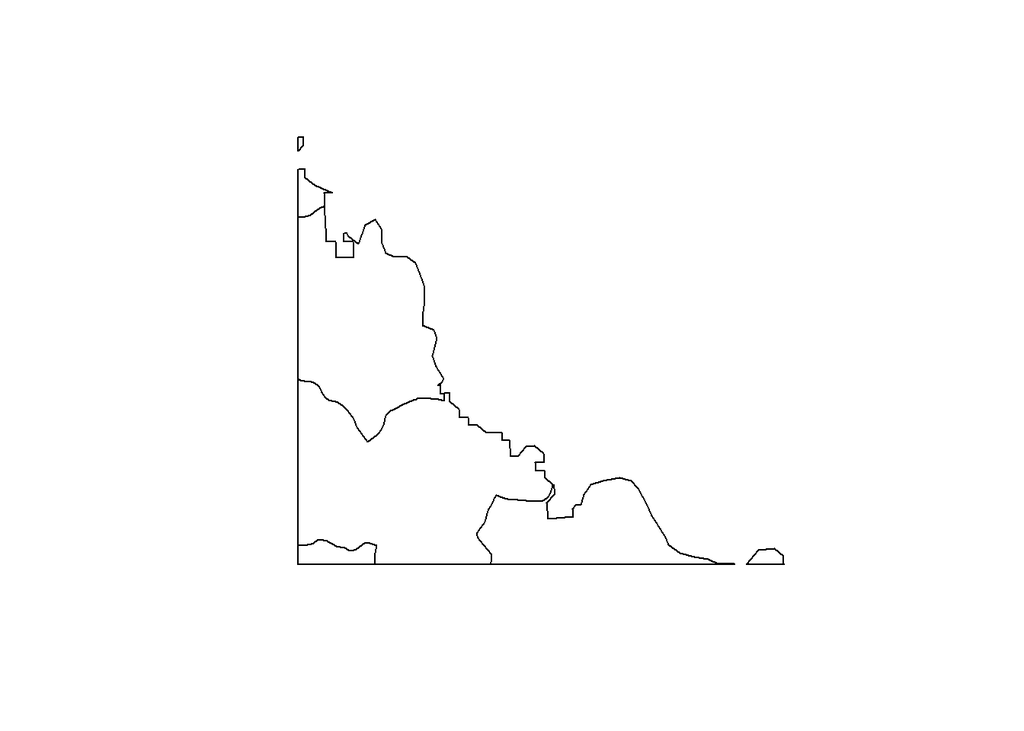

```r
## ---- int-------------------
i <- intersect(p, z2)
plot(i)
```

```r
# This is equivalent to
## -----------------------
i <- p * z2
```

Puede hacer intersecciones con un rectangulo:

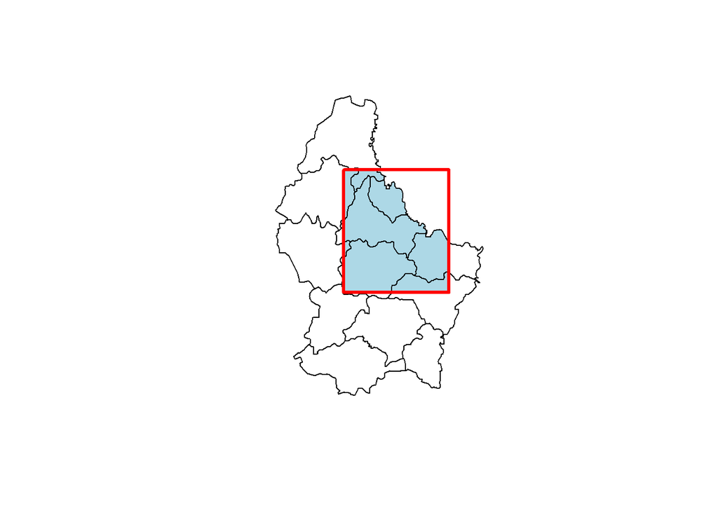

```r
## ---- intext----------
e <- extent(6, 6.4, 49.7, 50)
pe <- crop(p, e)
plot(p)
plot(pe, col='light blue', add=TRUE)
plot(e, add=TRUE, lwd=3, col='red')
```

7.3.3 Union Obtenga la unión de SpatialPolygon* objects.

```r
## -------------------------
u <- union(p, z)
#This is equivalent to
## -------------------------
u <- p + z
## -------------------------
u
```

```
## class       : SpatialPolygonsDataFrame
## features    : 28
## extent      : 5.74414, 6.528252, 49.44781, 50.18162  (xmin, xmax, ymin, ymax)
## crs         : +proj=longlat +datum=WGS84 +no_defs +ellps=WGS84 +towgs84=0,0,0
## variables   : 6
## names       : Zone, ID_1,     NAME_1, ID_2,   NAME_2, AREA
## min values  :    1,    1,   Diekirch,    1, Capellen,   76
## max values  :    4,    3, Luxembourg,   12,    Wiltz,  312
```

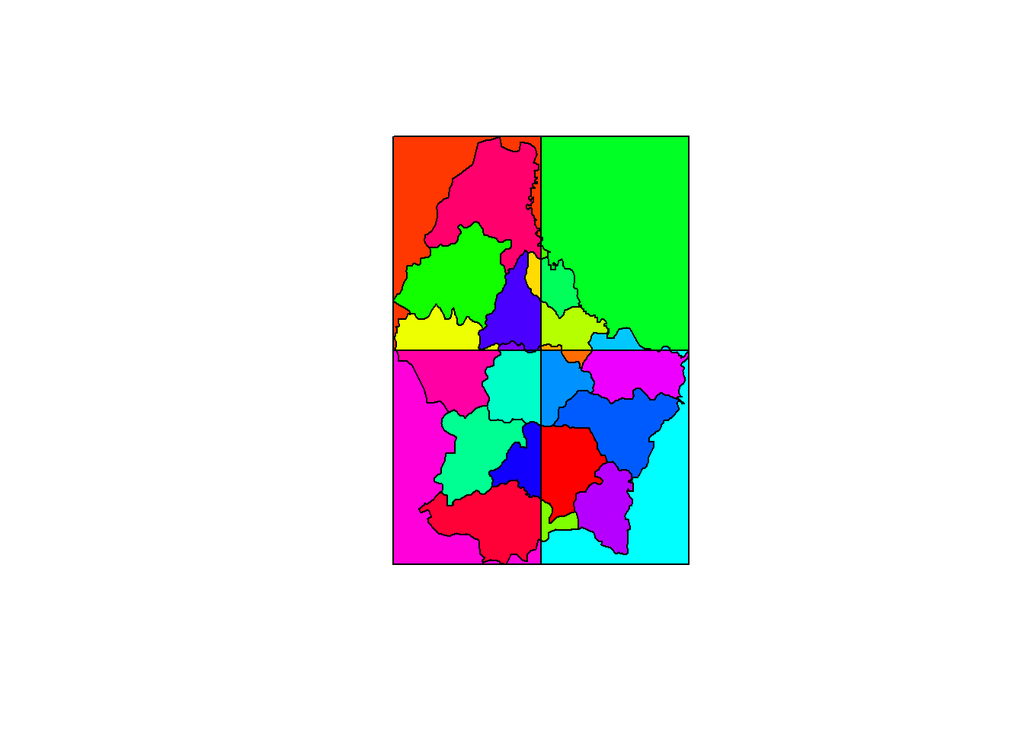

```r
set.seed(5)
plot(u, col=sample(rainbow(length(u))))
```

7.3.4 Covertura Cover is a combination of intersect and union (union de intersecciones de cada parte)

```r
## ---- cov---------------
cov <- cover(p, z)
cov
```

```
## class       : SpatialPolygonsDataFrame
## features    : 6
## extent      : 5.74414, 6.528252, 49.44781, 50.18162  (xmin, xmax, ymin, ymax)
## crs         : +proj=longlat +datum=WGS84 +no_defs +ellps=WGS84 +towgs84=0,0,0
## variables   : 6
## names       : ID_1,       NAME_1, ID_2,     NAME_2, AREA, Zone
## min values  :    1,     Diekirch,    1,   Clervaux,  188,    1
## max values  :    2, Grevenmacher,    6, Echternach,  312,    4
```

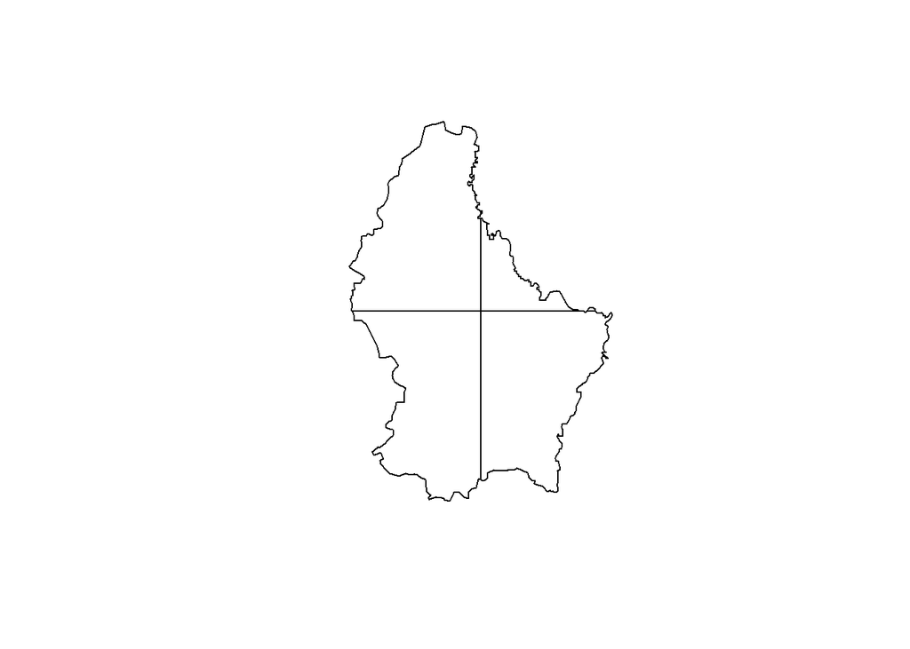

```r
plot(cov)
```

7.3.4 Difference The symmetrical difference of two SpatialPolygons* objects

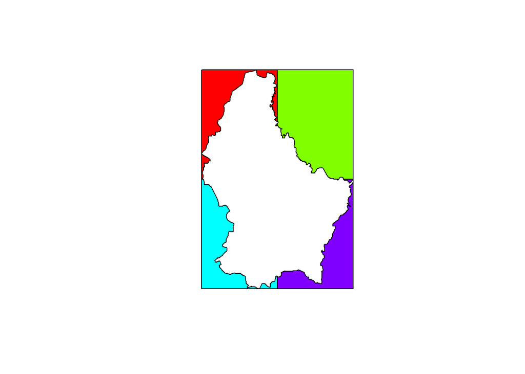

```r
## ---- dif----------------
dif <- symdif(z,p)
plot(dif, col=rainbow(length(dif)))
```

```r
dif
```

```
## class       : SpatialPolygonsDataFrame
## features    : 4
## extent      : 5.74414, 6.528252, 49.44781, 50.18162  (xmin, xmax, ymin, ymax)
## crs         : +proj=longlat +datum=WGS84 +no_defs +ellps=WGS84 +towgs84=0,0,0
## variables   : 1
## names       : Zone
## min values  :    1
## max values  :    4
```

## Manipulación de rasters

### Introduction

In this chapter general aspects of the design of the raster package are discussed, notably the structure of the main classes, and what they represent. The use of the package is illustrated in subsequent sections. raster has a large number of functions, not all of them are discussed here, and those that are discussed are mentioned only briefly. See the help files of the package for more information on individual functions and help(“raster-package”) for an index of functions by topic.

### Creating Raster* objects

A RasterLayer can easily be created from scratch using the function raster. The default settings will create a global raster data structure with a longitude/latitude coordinate reference system and 1 by 1 degree cells. You can change these settings by providing additional arguments such as xmn, nrow, ncol, and/or crs, to the function. You can also change these parameters after creating the object. If you set the projection, this is only to properly define it, not to change it. To transform a RasterLayer to another coordinate reference system (projection) you can use the function projectRaster.

Here is an example of creating and changing a RasterLayer object ‘r’ from scratch.

```r
## ---- raster-1a----------------------------------------------------------
library(raster)
# RasterLayer with the default parameters
x <- raster()
x
```

```
## class      : RasterLayer
## dimensions : 180, 360, 64800  (nrow, ncol, ncell)
## resolution : 1, 1  (x, y)
## extent     : -180, 180, -90, 90  (xmin, xmax, ymin, ymax)
## crs        : +proj=longlat +datum=WGS84 +ellps=WGS84 +towgs84=0,0,0
```

With some other parameters

```r
## ---- raster-1b----------------------------------------------------------
x <- raster(ncol=36, nrow=18, xmn=-1000, xmx=1000, ymn=-100, ymx=900)
```

These parameters can be changed. Resolution:

```r
## ---- raster-1c----------------------------------------------------------
res(x)
```

```
## [1] 55.55556 55.55556
```

```r
res(x) <- 100
res(x)
```

```
## [1] 100 100
```

Change the number of columns (this affects the resolution).

```r
## ---- raster-1d----------------------------------------------------------
ncol(x)
```

```
## [1] 20
```

```r
ncol(x) <- 18
ncol(x)
```

```
## [1] 18
```

```r
res(x)
```

```
## [1] 111.1111 100.0000
```

Set the coordinate reference system (CRS) (i.e., define the projection).

```r
## ---- raster-1e----------------------------------------------------------
projection(x) <- "+proj=utm +zone=48 +datum=WGS84"
x
```

```
## class      : RasterLayer
## dimensions : 10, 18, 180  (nrow, ncol, ncell)
## resolution : 111.1111, 100  (x, y)
## extent     : -1000, 1000, -100, 900  (xmin, xmax, ymin, ymax)
## crs        : +proj=utm +zone=48 +datum=WGS84 +ellps=WGS84 +towgs84=0,0,0
```

The objects x created in the examples above only consist of the raster ‘geometry’, that is, we have defined the number of rows and columns, and where the raster is located in geographic space, but there are no cell-values associated with it. Setting and accessing values is illustrated below.

First another example empty raster geometry.

```r
## ---- raster-1h----------------------------------------------------------
r <- raster(ncol=10, nrow=10)
ncell(r)
```

```
## [1] 100
```

```r
hasValues(r)
```

```
## [1] FALSE
```

Use the ‘values’ function.

```r
## ---- raster-1i----------------------------------------------------------
values(r) <- 1:ncell(r)
```

Another example:

```r
## ---- raster-1j----------------------------------------------------------
set.seed(0)
values(r) <- runif(ncell(r))

hasValues(r)
```

```
## [1] TRUE
```

```r
inMemory(r)
```

```
## [1] TRUE
```

```r
values(r)[1:10]
```

```
##  [1] 0.8966972 0.2655087 0.3721239 0.5728534 0.9082078 0.2016819 0.8983897
##  [8] 0.9446753 0.6607978 0.6291140
```

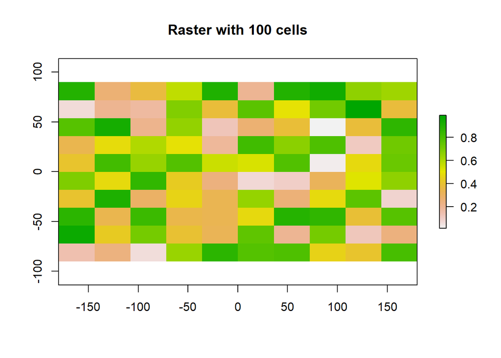

```r
plot(r, main='Raster with 100 cells')
```

In some cases, for example when you change the number of columns or rows, you will lose the values associated with the RasterLayer if there were any (or the link to a file if there was one). The same applies, in most cases, if you change the resolution directly (as this can affect the number of rows or columns). Values are not lost when changing the extent as this change adjusts the resolution, but does not change the number of rows or columns.

```r
## ---- raster-1x----------------------------------------------------------
hasValues(r)
```

```
## [1] TRUE
```

```r
res(r)
```

```
## [1] 36 18
```

```r
dim(r)
```

```
## [1] 10 10  1
```

```r
xmax(r)
```

```
## [1] 180
```

Now change the maximum x coordinate of the extent (bounding box) of the RasterLayer.

```r
## ---- raster-1y----------------------------------------------------------
xmax(r) <- 0
hasValues(r)
```

```
## [1] TRUE
```

```r
res(r)
```

```
## [1] 18 18
```

```r
dim(r)
```

```
## [1] 10 10  1
```

And the number of columns (the values disappear)

```r
## ---- raster-1z----------------------------------------------------------
ncol(r) <- 6
hasValues(r)
```

```
## [1] FALSE
```

```r
res(r)
```

```
## [1] 30 18
```

```r
dim(r)
```

```
## [1] 10  6  1
```

```r
xmax(r)
```

```
## [1] 0
```

The function raster also allows you to create a RasterLayer from another object, including another RasterLayer, RasterStack and RasterBrick , as well as from a SpatialPixels* and SpatialGrid* object (defined in the sp package), an Extent object, a matrix, an im object (spatstat package), and others.

It is more common, however, to create a RasterLayer object from a file. The raster package can use raster files in several formats, including some ‘natively’ supported formats and other formats via the rgdal package. Supported formats for reading include GeoTiff, ESRI, ENVI, and ERDAS. Most formats supported for reading can also be written to. Here is an example using the ‘Meuse’ dataset (taken from the sp package), using a file in the native ‘raster-file’ format.

A notable feature of the raster package is that it can work with raster datasets that are stored on disk and are too large to be loaded into memory (RAM). The package can work with large files because the objects it creates from these files only contain information about the structure of the data, such as the number of rows and columns, the spatial extent, and the filename, but it does not attempt to read all the cell values in memory. In computations with these objects, data is processed in chunks. If no output filename is specified to a function, and the output raster is too large to keep in memory, the results are written to a temporary file.

For this example, we first we get the name of an example file installed with the package. Do not use this system.file construction of your own files (just type the file name; don’t forget the forward slashes).

```r
## ---- raster-2a1---------------------------------------------------------
filename <- system.file("external/test.grd", package="raster")
filename
```

```
## [1] "C:/Users/Pedro Montenegro/Documents/R/win-library/3.6/raster/external/test.grd"
```

```r
## ---- raster-2a2---------------------------------------------------------
r <- raster(filename)
filename(r)
```

```
## [1] "C:\\Users\\Pedro Montenegro\\Documents\\R\\win-library\\3.6\\raster\\external\\test.grd"
```

```r
hasValues(r)
```

```
## [1] TRUE
```

```r
inMemory(r)
```

```
## [1] FALSE
```

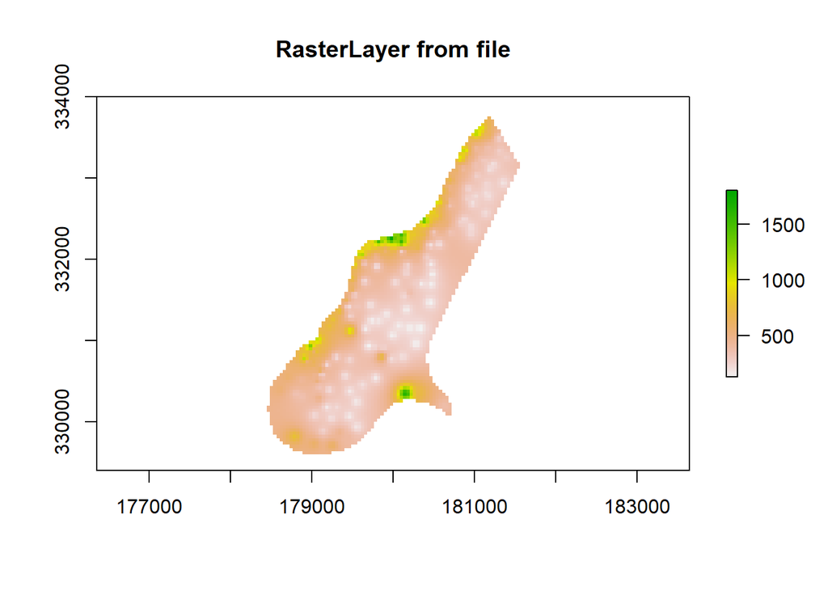

```r
plot(r, main='RasterLayer from file')
```

Multi-layer objects can be created in memory (from RasterLayer objects) or from files.

Create three identical RasterLayer objects

```r
## ---- raster-2b1---------------------------------------------------------
r1 <- r2 <- r3 <- raster(nrow=10, ncol=10)
# Assign random cell values
values(r1) <- runif(ncell(r1))
values(r2) <- runif(ncell(r2))
values(r3) <- runif(ncell(r3))
```

Combine three RasterLayer objects into a RasterStack.

```r
## ---- raster-2b2---------------------------------------------------------
s <- stack(r1, r2, r3)
s
```

```
## class      : RasterStack
## dimensions : 10, 10, 100, 3  (nrow, ncol, ncell, nlayers)
## resolution : 36, 18  (x, y)
## extent     : -180, 180, -90, 90  (xmin, xmax, ymin, ymax)
## crs        : +proj=longlat +datum=WGS84 +ellps=WGS84 +towgs84=0,0,0
## names      :    layer.1,    layer.2,    layer.3
## min values : 0.01307758, 0.02778712, 0.06380247
## max values :  0.9926841,  0.9815635,  0.9960774
```

```r
nlayers(s)
```

```
## [1] 3
```

Or combine the RasterLayer objects into a RasterBrick.

```r
## ---- raster-2b3---------------------------------------------------------
b1 <- brick(r1, r2, r3)
```

This is equivalent to:

```r
## ---- raster-2b4---------------------------------------------------------
b2 <- brick(s)
```

You can also create a RasterBrick from a file.

```r
## ---- raster-2b5---------------------------------------------------------
filename <- system.file("external/rlogo.grd", package="raster")
filename
```

```
## [1] "C:/Users/Pedro Montenegro/Documents/R/win-library/3.6/raster/external/rlogo.grd"
```

```r
b <- brick(filename)
b
```

```
## class      : RasterBrick
## dimensions : 77, 101, 7777, 3  (nrow, ncol, ncell, nlayers)
## resolution : 1, 1  (x, y)
## extent     : 0, 101, 0, 77  (xmin, xmax, ymin, ymax)
## crs        : +proj=merc +datum=WGS84 +ellps=WGS84 +towgs84=0,0,0
## source     : C:/Users/Pedro Montenegro/Documents/R/win-library/3.6/raster/external/rlogo.grd
## names      : red, green, blue
## min values :   0,     0,    0
## max values : 255,   255,  255
```

```r
nlayers(b)
```

```
## [1] 3
```

Extract a single RasterLayer from a RasterBrick (or RasterStack).

```r
## ---- raster-2b6---------------------------------------------------------
r <- raster(b, layer=2)
```

In this case, that would be equivalent to creating it from disk with a band=2 argument.

```r
## ---- raster-2b7---------------------------------------------------------
r <- raster(filename, band=2)
```

Raster algebra

Create an empty RasterLayer and assign values to cells.

```r
## ---- raster-3a1---------------------------------------------------------
r <- raster(ncol=10, nrow=10)
values(r) <- 1:ncell(r)
```

Now some algebra.

```r
## ---- raster-3a2---------------------------------------------------------
s <- r + 10
s <- sqrt(s)
s <- s * r + 5
r[] <- runif(ncell(r))
r <- round(r)
r <- r == 1
```

You can also use replacement functions.

```r
## ---- raster-3b----------------------------------------------------------
s[r] <- -0.5
s[!r] <- 5
s[s == 5] <- 15
```

If you use multiple Raster objects (in functions where this is relevant, such as range), these must have the same resolution and origin. The origin of a Raster object is the point closest to (0, 0) that you could get if you moved from a corners of a Raster object toward that point in steps of the x and y resolution. Normally these objects would also have the same extent, but if they do not, the returned object covers the spatial intersection of the objects used.

```r
## ---- raster-3c----------------------------------------------------------
r <- raster(ncol=5, nrow=5)
r[] <- 1
s <- stack(r, r+1)
q <- stack(r, r+2, r+4, r+6)
x <- r + s + q
x
```

```
## class      : RasterBrick
## dimensions : 5, 5, 25, 4  (nrow, ncol, ncell, nlayers)
## resolution : 72, 36  (x, y)
## extent     : -180, 180, -90, 90  (xmin, xmax, ymin, ymax)
## crs        : +proj=longlat +datum=WGS84 +ellps=WGS84 +towgs84=0,0,0
## source     : memory
## names      : layer.1, layer.2, layer.3, layer.4
## min values :       3,       6,       7,      10
## max values :       3,       6,       7,      10
```

Summary functions (min, max, mean, prod, sum, Median, cv, range, any, all) always return a RasterLayer object. Perhaps this is not obvious when using functions like min, sum or mean.

```r
## ---- raster-3d----------------------------------------------------------
a <- mean(r,s,10)
b <- sum(r,s)
st <- stack(r, s, a, b)
sst <- sum(st)
sst
```

```
## class      : RasterLayer
## dimensions : 5, 5, 25  (nrow, ncol, ncell)
## resolution : 72, 36  (x, y)
## extent     : -180, 180, -90, 90  (xmin, xmax, ymin, ymax)
## crs        : +proj=longlat +datum=WGS84 +ellps=WGS84 +towgs84=0,0,0
## source     : memory
## names      : layer
## values     : 11.5, 11.5  (min, max)
```

Use cellStats if instead of a RasterLayer you want a single number summarizing the cell values of each layer.

```r
## ---- raster-3e----------------------------------------------------------
cellStats(st, 'sum')
```

```
## layer.1.1 layer.1.2 layer.2.1 layer.2.2   layer.3
##      25.0      25.0      50.0      87.5     100.0
```

```r
cellStats(sst, 'sum')
```

```
## [1] 287.5
```

‘High-level’ functions

Several ‘high level’ functions have been implemented for RasterLayer objects. ‘High level’ functions refer to functions that you would normally find in a computer program that supports the analysis of raster data. Here we briefly discuss some of these functions. All these functions work for raster datasets that cannot be loaded into memory. See the help files for more detailed descriptions of each function.

The high-level functions have some arguments in common. The first argument is typically ‘x’ or ‘object’ and can be a RasterLayer, or, in most cases, a RasterStack or RasterBrick. It is followed by one or more arguments specific to the function (either additional RasterLayer objects or other arguments), followed by a filename=”” and ”…” arguments.

The default filename is an empty character “”. If you do not specify a filename, the default action for the function is to return a raster object that only exists in memory. However, if the function deems that the raster object to be created would be too large to hold memory it is written to a temporary file instead.

The ”…” argument allows for setting additional arguments that are relevant when writing values to a file: the file format, datatype (e.g. integer or real values), and a to indicate whether existing files should be overwritten.

Modifying a Raster* object

There are several functions that deal with modifying the spatial extent of Raster objects. The crop function lets you take a geographic subset of a larger raster object. You can crop a Raster by providing an extent object or another spatial object from which an extent can be extracted (objects from classes deriving from Raster and from Spatial in the sp package). An easy way to get an extent object is to plot a RasterLayer and then use drawExtent to visually determine the new extent (bounding box) to provide to the crop function.

trim crops a RasterLayer by removing the outer rows and columns that only contain NA values. In contrast, extend adds new rows and/or columns with NA values. The purpose of this could be to create a new RasterLayer with the same Extent of another larger RasterLayer such that the can be used together in other functions.

The merge function lets you merge 2 or more Raster objects into a single new object. The input objects must have the same resolution and origin (such that their cells neatly fit into a single larger raster). If this is not the case you can first adjust one of the Raster objects with use (dis)aggregate or resample.

aggregate and disaggregate allow for changing the resolution (cell size) of a Raster object. In the case of aggregate, you need to specify a function determining what to do with the grouped cell values mean. It is possible to specify different (dis)aggregation factors in the x and y direction. aggregate and disaggregate are the best functions when adjusting cells size only, with an integer step (e.g. each side 2 times smaller or larger), but in some cases that is not possible.

For example, you may need nearly the same cell size, while shifting the cell centers. In those cases, the resample function can be used. It can do either nearest neighbor assignments (for categorical data) or bilinear interpolation (for numerical data). Simple linear shifts of a Raster object can be accomplished with the shift function or with the extent function. resample should not be used to create a Raster* object with much larger resolution. If such adjustments need to be made then you can first use aggregate.

With the projectRaster function you can transform values of Raster object to a new object with a different coordinate reference system.

Here are some simple examples.

Aggregate and disaggregate.

```r
## ---- raster-5, fig.width=9, fig.height=4--------------------------------
r <- raster()
r[] <- 1:ncell(r)
ra <- aggregate(r, 20)
rd <- disaggregate(ra, 20)
```

Crop and merge example.

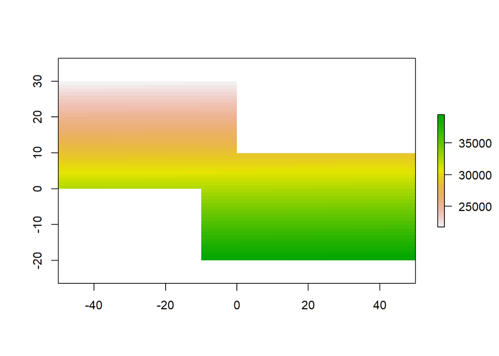

```r
## ---- raster-5b, fig.width=9, fig.height=4-------------------------------
r1 <- crop(r, extent(-50,0,0,30))
r2 <- crop(r, extent(-10,50,-20, 10))
m <- merge(r1, r2, filename='test.grd', overwrite=TRUE)
plot(m)
```

flip lets you flip the data (reverse order) in horizontal or vertical direction – typically to correct for a ‘communication problem’ between different R packages or a misinterpreted file. rotate lets you rotate longitude/latitude rasters that have longitudes from 0 to 360 degrees (often used by climatologists) to the standard -180 to 180 degrees system. With t you can rotate a Raster object 90 degrees.

Overlay The overlay function can be used as an alternative to the raster algebra discussed above. Overlay, like the functions discussed in the following subsections provide either easy to use short-hand, or more efficient computation for large (file based) objects.

With overlay you can combine multiple Raster objects (e.g. multiply them). The related function mask removes all values from one layer that are NA in another layer, and cover combines two layers by taking the values of the first layer except where these are NA.

Calc calc allows you to do a computation for a single raster object by providing a function. If you supply a RasterLayer, another RasterLayer is returned. If you provide a multi-layer object you get a (single layer) RasterLayer if you use a summary type function (e.g. sum but a RasterBrick if multiple layers are returned. stackApply computes summary type layers for subsets of a RasterStack or RasterBrick.

Reclassify You can use cut or reclassify to replace ranges of values with single values, or subs to substitute (replace) single values with other values.

```r
## ---- echo=FALSE, include=FALSE------------------------------------------
ff <- list.files(patt="^test")
file.remove(ff)
```

```
## [1] TRUE TRUE
```

```r
## ---- raster-6a----------------------------------------------------------
r <- raster(ncol=3, nrow=2)
r[] <- 1:ncell(r)
getValues(r)
```

```
## [1] 1 2 3 4 5 6
```

```r
## ---- raster-6b----------------------------------------------------------
s <- calc(r, fun=function(x){ x[x < 4] <- NA; return(x)} )
as.matrix(s)
```

```
##      [,1] [,2] [,3]
## [1,]   NA   NA   NA
## [2,]    4    5    6
```

Divide the first raster with two times the square root of the second raster and add five.

```r
## ---- raster-6c----------------------------------------------------------
w <- overlay(r, s, fun=function(x, y){ x / (2 * sqrt(y)) + 5 } )
as.matrix(w)
```

```
##      [,1]     [,2]     [,3]
## [1,]   NA       NA       NA
## [2,]    6 6.118034 6.224745
```

Remove from r all values that are NA in w.

```r
## ---- raster-6d----------------------------------------------------------
u <- mask(r, w)
as.matrix(u)
```

```
##      [,1] [,2] [,3]
## [1,]   NA   NA   NA
## [2,]    4    5    6
```

Identify the cell values in u that are the same as in s.

```r
## ---- raster-6e----------------------------------------------------------
v <- u==s
as.matrix(v)
```

```
##      [,1] [,2] [,3]
## [1,]   NA   NA   NA
## [2,] TRUE TRUE TRUE
```

Replace NA values in w with values of r.

```r
## ---- raster-6f----------------------------------------------------------
cvr <- cover(w, r)
as.matrix(w)
```

```
##      [,1]     [,2]     [,3]
## [1,]   NA       NA       NA
## [2,]    6 6.118034 6.224745
```

Change value between 0 and 2 to 1, etc.

```r
## ---- raster-6g----------------------------------------------------------
x <- reclassify(w, c(0,2,1,  2,5,2, 4,10,3))
as.matrix(x)
```

```
##      [,1] [,2] [,3]
## [1,]   NA   NA   NA
## [2,]    3    3    3
```

Substitute 2 with 40 and 3 with 50.

```r
## ---- raster-6h----------------------------------------------------------
y <- subs(x, data.frame(id=c(2,3), v=c(40,50)))
as.matrix(y)
```

```
##      [,1] [,2] [,3]
## [1,]   NA   NA   NA
## [2,]   50   50   50
```

Focal functions

The focal function currently only work for (single layer) RasterLayer objects. They make a computation using values in a neighborhood of cells around a focal cell, and putting the result in the focal cell of the output RasterLayer. The neighborhood is a user-defined matrix of weights and could approximate any shape by giving some cells zero weight. It is possible to only computes new values for cells that are NA in the input RasterLayer.

Distance

There are a number of distance related functions. distance computes the shortest distance to cells that are not NA. pointDistance computes the shortest distance to any point in a set of points. gridDistance computes the distance when following grid cells that can be traversed (e.g. excluding water bodies). direction computes the direction toward (or from) the nearest cell that is not NA. adjacency determines which cells are adjacent to other cells. See the gdistance package for more advanced distance calculations (cost distance, resistance distance)

Spatial configuration

Function clump identifies groups of cells that are connected. boundaries identifies edges, that is, transitions between cell values. area computes the size of each grid cell (for unprojected rasters), this may be useful to, e.g. compute the area covered by a certain class on a longitude/latitude raster.

```r
## ---- raster-7-----------------------------------------------------------
r <- raster(nrow=45, ncol=90)
r[] <- round(runif(ncell(r))*3)
a <- area(r)
zonal(a, r, 'sum')
```

```
##      zone       sum
## [1,]    0  93604336
## [2,]    1 168894837
## [3,]    2 158110025
## [4,]    3  87822040
```

Predictions

The package has two functions to make model predictions to (potentially very large) rasters. predict takes a multilayer raster and a fitted model as arguments. Fitted models can be of various classes, including glm, gam, and RandomForest. The function interpolate is similar but is for models that use coordinates as predictor variables, for example in Kriging and spline interpolation.

Vector to raster conversion

The raster packages supports point, line, and polygon to raster conversion with the rasterize function. For vector type data (points, lines, polygons), objects of Spatial* classes defined in the sp package are used; but points can also be represented by a two-column matrix (x and y).

Point to raster conversion is often done with the purpose to analyze the point data. For example to count the number of distinct species (represented by point observations) that occur in each raster cell. rasterize takes a Raster object to set the spatial extent and resolution, and a function to determine how to summarize the points (or an attribute of each point) by cell.

Polygon to raster conversion is typically done to create a RasterLayer that can act as a mask, i.e. to set to NA a set of cells of a raster object, or to summarize values on a raster by zone. For example a country polygon is transferred to a raster that is then used to set all the cells outside that country to NA; whereas polygons representing administrative regions such as states can be transferred to a raster to summarize raster values by region.

It is also possible to convert the values of a RasterLayer to points or polygons, using rasterToPoints and rasterToPolygons. Both functions only return values for cells that are not NA. Unlike rasterToPolygons, rasterToPoints is reasonably efficient and allows you to provide a function to subset the output before it is produced (which can be necessary for very large rasters as the point object is created in memory).

Summarizing functions

When used with a Raster object as first argument, normal summary statistics functions such as min, max and mean return a RasterLayer. You can use cellStats if, instead, you want to obtain a summary for all cells of a single Raster object. You can use freq to make a frequency table, or to count the number of cells with a specified value. Use zonal to summarize a Raster object using zones (areas with the same integer number) defined in a RasterLayer and crosstab to cross-tabulate two RasterLayer objects.

```r
## ---- raster-10a---------------------------------------------------------
r <- raster(ncol=36, nrow=18)
r[] <- runif(ncell(r))
cellStats(r, mean)
```

```
## [1] 0.5179682
```

Zonal stats

```r
## ---- raster-10b---------------------------------------------------------
s <- r
s[] <- round(runif(ncell(r)) * 5)
zonal(r, s, 'mean')
```

```
##      zone      mean
## [1,]    0 0.5144431
## [2,]    1 0.5480089
## [3,]    2 0.5249257
## [4,]    3 0.5194031
## [5,]    4 0.4853966
## [6,]    5 0.5218401
```

Count cells

```r
## ---- raster-10c---------------------------------------------------------
freq(s)
```

```
##      value count
## [1,]     0    54
## [2,]     1   102
## [3,]     2   139
## [4,]     3   148
## [5,]     4   133
## [6,]     5    72
```

```r
freq(s, value=3)
```

```
## [1] 148
```

Cross-tabulate

```r
## ---- raster-10d---------------------------------------------------------
ctb <- crosstab(r*3, s)
head(ctb)
```

```
##        layer.2
## layer.1  0  1  2  3  4  5
##       0  8 13 21 16 24 10
##       1 17 31 42 56 45 24
##       2 19 31 52 54 37 27
##       3 10 27 24 22 27 11
```

Helper functions

The cell number is an important concept in the raster package. Raster data can be thought of as a matrix, but in a RasterLayer it is more commonly treated as a vector. Cells are numbered from the upper left cell to the upper right cell and then continuing on the left side of the next row, and so on until the last cell at the lower-right side of the raster. There are several helper functions to determine the column or row number from a cell and vice versa, and to determine the cell number for x, y coordinates and vice versa.

```r
## ---- raster-15----------------------------------------------------------
library(raster)
r <- raster(ncol=36, nrow=18)
ncol(r)
```

```
## [1] 36
```

```r
nrow(r)
```

```
## [1] 18
```

```r
ncell(r)
```

```
## [1] 648
```

```r
rowFromCell(r, 100)
```

```
## [1] 3
```

```r
colFromCell(r, 100)
```

```
## [1] 28
```

```r
cellFromRowCol(r,5,5)
```

```
## [1] 149
```

```r
xyFromCell(r, 100)
```

```
##       x  y
## [1,] 95 65
```

```r
cellFromXY(r, c(0,0))
```

```
## [1] 343
```

```r
colFromX(r, 0)
```

```
## [1] 19
```

```r
rowFromY(r, 0)
```

```
## [1] 10
```

Accessing cell values

Cell values can be accessed with several methods. Use getValues to get all values or a single row; and getValuesBlock to read a block (rectangle) of cell values.

```r
## ---- raster-20----------------------------------------------------------
r <- raster(system.file("external/test.grd", package="raster"))
v <- getValues(r, 50)
v[35:39]
```

```
## [1] 456.878 485.538 550.788 580.339 590.029
```

```r
getValuesBlock(r, 50, 1, 35, 5)
```

```
## [1] 456.878 485.538 550.788 580.339 590.029
```

You can also read values using cell numbers or coordinates (xy) using the extract method.

```r
## ---- raster-21----------------------------------------------------------
cells <- cellFromRowCol(r, 50, 35:39)
cells
```

```
## [1] 3955 3956 3957 3958 3959
```

```r
extract(r, cells)
```

```
## [1] 456.878 485.538 550.788 580.339 590.029
```

```r
xy <- xyFromCell(r, cells)
xy
```

```
##           x      y
## [1,] 179780 332020
## [2,] 179820 332020
## [3,] 179860 332020
## [4,] 179900 332020
## [5,] 179940 332020
```

```r
extract(r, xy)
```

```
## [1] 456.878 485.538 550.788 580.339 590.029
```

You can also extract values using SpatialPolygons* or SpatialLines*. The default approach for extracting raster values with polygons is that a polygon has to cover the center of a cell, for the cell to be included. However, you can use argument “weights=TRUE” in which case you get, apart from the cell values, the percentage of each cell that is covered by the polygon, so that you can apply, e.g., a “50% area covered” threshold, or compute an area-weighted average.

In the case of lines, any cell that is crossed by a line is included. For lines and points, a cell that is only ‘touched’ is included when it is below or to the right (or both) of the line segment/point (except for the bottom row and right-most column).

In addition, you can use standard R indexing to access values, or to replace values (assign new values to cells) in a raster object. If you replace a value in a raster object based on a file, the connection to that file is lost (because it now is different from that file). Setting raster values for very large files will be very slow with this approach as each time a new (temporary) file, with all the values, is written to disk. If you want to overwrite values in an existing file, you can use update (with caution!)

```r
## ---- raster-32----------------------------------------------------------
r[cells]
```

```
## [1] 456.878 485.538 550.788 580.339 590.029
```

```r
r[1:4]
```

```
## [1] NA NA NA NA
```

```r
filename(r)
```

```
## [1] "C:\\Users\\Pedro Montenegro\\Documents\\R\\win-library\\3.6\\raster\\external\\test.grd"
```

```r
r[2:3] <- 10
r[1:4]
```

```
## [1] NA 10 10 NA
```

```r
filename(r)
```

```
## [1] ""
```

Note that in the above examples values are retrieved using cell numbers. That is, a raster is represented as a (one-dimensional) vector. Values can also be inspected using a (two-dimensional) matrix notation. As for R matrices, the first index represents the row number, the second the column number.

```r
## ---- raster-33----------------------------------------------------------
r[1]
```

```
## [1] NA
```

```r
r[2,2]
```

```
## [1] NA
```

```r
r[1,]
```

```
##  [1] NA 10 10 NA NA NA NA NA NA NA NA NA NA NA NA NA NA NA NA NA NA NA NA
## [24] NA NA NA NA NA NA NA NA NA NA NA NA NA NA NA NA NA NA NA NA NA NA NA
## [47] NA NA NA NA NA NA NA NA NA NA NA NA NA NA NA NA NA NA NA NA NA NA NA
## [70] NA NA NA NA NA NA NA NA NA NA NA
```

```r
r[,2]
```

```
##   [1]  10.000      NA      NA      NA      NA      NA      NA      NA
##   [9]      NA      NA      NA      NA      NA      NA      NA      NA
##  [17]      NA      NA      NA      NA      NA      NA      NA      NA
##  [25]      NA      NA      NA      NA      NA      NA      NA      NA
##  [33]      NA      NA      NA      NA      NA      NA      NA      NA
##  [41]      NA      NA      NA      NA      NA      NA      NA      NA
##  [49]      NA      NA      NA      NA      NA      NA      NA      NA
##  [57]      NA      NA      NA      NA      NA      NA      NA      NA
##  [65]      NA      NA      NA      NA      NA      NA      NA      NA
##  [73]      NA      NA      NA      NA      NA      NA      NA      NA
##  [81]      NA      NA      NA      NA      NA      NA      NA      NA
##  [89]      NA      NA      NA      NA      NA      NA      NA 473.833
##  [97] 471.573      NA      NA      NA      NA      NA      NA      NA
## [105]      NA      NA      NA      NA      NA      NA      NA      NA
## [113]      NA      NA      NA
```

```r
r[1:3,1:3]
```

```
## [1] NA 10 10 NA NA NA NA NA NA
```

```r
# keep the matrix structure
r[1:3,1:3, drop=FALSE]
```

```
## class      : RasterLayer
## dimensions : 3, 3, 9  (nrow, ncol, ncell)
## resolution : 40, 40  (x, y)
## extent     : 178400, 178520, 333880, 334000  (xmin, xmax, ymin, ymax)
## crs        : +proj=sterea +lat_0=52.15616055555555 +lon_0=5.38763888888889 +k=0.9999079 +x_0=155000 +y_0=463000 +ellps=bessel +units=m +towgs84=565.237,50.0087,465.658,-0.406857,0.350733,-1.87035,4.0812 +no_defs
## source     : memory
## names      : layer
## values     : 10, 10  (min, max)
```

Accessing values through this type of indexing should be avoided inside functions as it is less efficient than accessing values via functions like getValues.

Coercion to other classes

Although the raster package defines its own set of classes, it is easy to coerce objects of these classes to objects of the Spatial family defined in the sp package. This allows for using functions defined by sp (e.g. spplot) and for using other packages that expect Spatial* objects. To create a Raster object from variable n in a SpatialGrid* x use raster(x, n) or stack(x) or brick(x). Vice versa use as( , ). You can also convert objects of class im (spatstat) and others to a RasterLayer using the raster, stack or brick functions.

```r
## ---- raster-120---------------------------------------------------------
r1 <- raster(ncol=36, nrow=18)
r2 <- r1
r1[] <- runif(ncell(r1))
r2[] <- runif(ncell(r1))
s <- stack(r1, r2)
sgdf <- as(s, 'SpatialGridDataFrame')
newr2 <- raster(sgdf, 2)
news <- stack(sgdf)
```

Nota: [aquí](http://daticos-geotec.opendata.arcgis.com/datasets/249bc8711c33493a90b292b55ed3abad_0?selectedAttributes%5B%5D=COD_CANT&chartType=bar) pueden encontrar los shp files de Costa Rica.